# Mô hình Random Forest

Ho Duc Ninh

May 4, 2017

# 1 Lí thuyết

1. Hạn chế của Decision tree:
- Sai số lớn
- Overfitting
- Thực tế kém chính xác hơn các phương pháp khác
2. Biện pháp khắc phục: Bagging
- Giảm sai số bằng phương pháp lấy trung bình
- Bagging: xây dựng nhiều tree từ các subset của training data

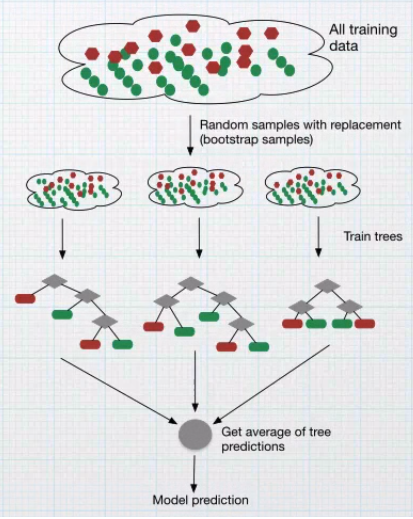

Tuy nhiên: Những trees này highly correlated do các trees có xu hướng dùng cùng một tập hợp biến đầu vào.

3. Biện pháp khắc phục(decorrelate trees): Random Forest
- Sử dụng phương pháp giống với Bagging
- Tuy nhiên, với mỗi tree, chỉ lựa chọn m~sqrt(p)(hoặc p/3) biến đầu vào

Lưu ý: nếu m->p, randomForest->bagging

# 2 Thực hành

```r
#Load library and data
library(dplyr)
library(ggplot2)
library(randomForest)

load("C:/data.Rda")
```

## 2.1 Bài toán

Phân biệt âm ‘m’ và ‘n’ từ 617 biến đầu vào.

```r
data[c(1:5,597:599),c(1,615:dim(data)[2])]
```

```
##           V1    V615    V616    V617 letter isTest testlabel
## 25   -0.2116  0.7664  0.4598  0.2700      m  FALSE     train
## 26   -0.5672  0.3334 -0.3612 -0.7500      m  FALSE     train
## 27   -0.5160  0.3948  0.3684  0.1578      n  FALSE     train
## 28   -0.5330  0.2748 -0.0550 -0.8462      n  FALSE     train
## 77    0.0326 -0.5744 -0.6596 -0.7022      m  FALSE     train
## 7771 -0.6426  0.2210  0.3052 -0.2632      m   TRUE      test
## 7772 -0.7230 -0.0350  0.0176 -0.7018      n   TRUE      test
## 7773 -0.6600  0.1048  0.4666  0.0096      n   TRUE      test
```

## 2.2 Các bước xây dựng model trong R

**1. train và test dataset được chia theo tỉ lệ 4:1**

```r
data$testlabel %>% table
```

```
## .
## train  test
##   480   119
```

**2. Xác định các biến đầu vào và đầu ra**

Target variable : ‘n’

```r
vars <- colnames(data)[1:617]
yColumn <- "isN"
data[,yColumn] <- data[,'letter'] == 'n'
table(data[,yColumn])/nrow(data)
```

```
##
##     FALSE      TRUE
## 0.4991653 0.5008347
```

**3. Tạo một số hàm để thống kê performance của model**

```r
accuracy <- function(truth, pred){
  cm = table(truth, pred>0.5)
  sum(diag(cm))/sum(cm)
}

precision <- function(truth, pred){
  cm = table(truth, pred>0.5)
  sum(cm[2,2])/sum(cm[,2])
}

tpr <- function(truth, pred){
  cm = table(truth, pred>0.5)
  sum(cm[2,2])/sum(cm[2,])
}

stats <- function(data, test, modelName){
  dSub = data[data$isTest ==test,,drop = FALSE]
  acc = accuracy(dSub[,yColumn], dSub[,modelName])
  pre = precision(dSub[,yColumn], dSub[,modelName])
  tpr = tpr(dSub[,yColumn], dSub[,modelName])
  note = ifelse(test,'test','train')
  print(paste( note, 'accuracy', modelName, format(acc, digit = 2)))
  print(paste( note, 'precision', modelName, format(pre, digit = 2)))
  print(paste( note, 'true positive rate', modelName, format(tpr, digit = 2)))
}

report <- function(data, modelName){
  print("*************")
  stats(data, FALSE, modelName)
  stats(data, TRUE, modelName)
  print("*************")
}
```

**4. Chạy random Forest model**

```r
set.seed(1234)

model1 <- randomForest(x = data[!data$isTest, vars],
                       y = as.factor(data[!data$isTest,yColumn]),
                       importance = TRUE)
model1
```

```
##
## Call:
##  randomForest(x = data[!data$isTest, vars], y = as.factor(data[!data$isTest,      yColumn]), importance = TRUE)
##                Type of random forest: classification
##                      Number of trees: 500
## No. of variables tried at each split: 24
##
##         OOB estimate of  error rate: 6.46%
## Confusion matrix:
##       FALSE TRUE class.error
## FALSE   225   15  0.06250000
## TRUE     16  224  0.06666667
```

Out-of-Bag Error:

- Mỗi tree được xây dựng trên 2/3 của total training data và được test trên 1/3 training data còn lại

**5. Thực hiện dự báo trên tập dữ liệu**

```r
data$model1 <- predict(model1, newdata = data, type = 'prob')[,'TRUE', drop = TRUE]
```

**6. Performance report**

**6.1. Basic stats**

```r
report(data, 'model1')
```

```
## [1] "*************"
## [1] "train accuracy model1 1"
## [1] "train precision model1 1"
## [1] "train true positive rate model1 1"
## [1] "test accuracy model1 0.9"
## [1] "test precision model1 0.9"
## [1] "test true positive rate model1 0.9"
## [1] "*************"
```

**6.2. Density plot**

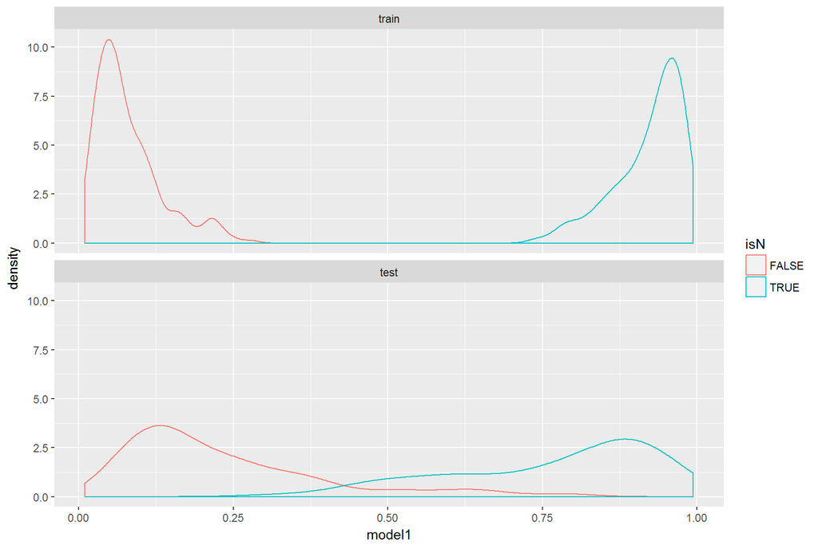

```r
ggplot()+
  geom_density(data = data, aes_string(x = "model1", color = yColumn)) +
  facet_wrap(~testlabel, ncol = 1)
```

**7. Variable importance**

Variable càng làm giảm chỉ số **accuracy** của model, variable được coi là **“important”**

**7.1. Plot**

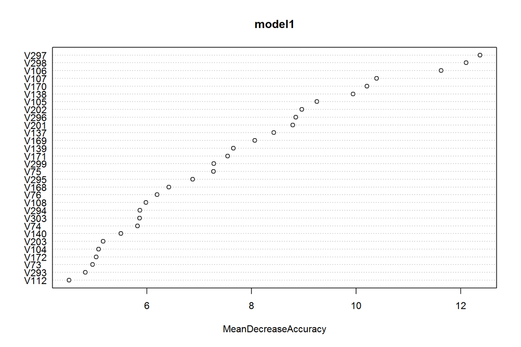

```r
varImpPlot(model1, type = 1)
```

**7.2. Chỉ số đánh giá variable importance**

```r
vImps <- importance(model1, class = 'TRUE')
head(vImps)
```

```
##          FALSE       TRUE MeanDecreaseAccuracy MeanDecreaseGini
## V1  1.70358921 -0.2807529          0.954354704       0.15944532
## V2  0.75828891 -0.3514930         -0.001309104       0.11606577
## V3  0.24637728 -0.2333422          0.008845723       0.12761402
## V4 -0.01764127  0.5192275          0.364547170       0.09468031
## V5  1.06356408  0.3920031          0.886826655       0.12681241
## V6  1.37308532  0.3854663          1.341584284       0.29790446
```

**7.3. Sắp xếp theo thứ tự và lấy 30 variables tốt nhất**

```r
ord <- order(vImps[,3], decreasing = TRUE)
vord = vImps[ord, 3]
head(vord)
```

```
##      V297      V298      V106      V107      V170      V138
## 12.368664 12.101248 11.621244 10.390515 10.207339  9.940631
```

```r
topvars = names(vord[1:30])
```

**7.4. Reduced model**

```r
model2 <- randomForest(x = data[!data$isTest, topvars],
                       y = as.factor(data[!data$isTest, yColumn]))
model2
```

```
##
## Call:
##  randomForest(x = data[!data$isTest, topvars], y = as.factor(data[!data$isTest,      yColumn]))
##                Type of random forest: classification
##                      Number of trees: 500
## No. of variables tried at each split: 5
##
##         OOB estimate of  error rate: 6.46%
## Confusion matrix:
##       FALSE TRUE class.error
## FALSE   222   18  0.07500000
## TRUE     13  227  0.05416667
```

```r
data$model2 <- predict(model2, newdata = data, type='prob')[, 'TRUE', drop = TRUE]

report(data, 'model2')
```

```
## [1] "*************"
## [1] "train accuracy model2 1"
## [1] "train precision model2 1"
## [1] "train true positive rate model2 1"
## [1] "test accuracy model2 0.91"
## [1] "test precision model2 0.9"
## [1] "test true positive rate model2 0.92"
## [1] "*************"
```

# 3 Tài liệu tham khảo

- Introduction to Statistical Learning with R
- R in Action
- https://github.com/WinVector/WinVector.github.io/blob/master/IntroductionToDataScience/Sec02_Lesson010_RFPractice/isolet.Rmd